# STAT 679: Problem Set #4

# Q1. Political Book Recommendations

**In this problem, we’ll study a network dataset of Amazon bestselling US Politics books. Books are linked by an edge if they appeared together in the recommendations (“customers who bought this book also bought these other books”).**

## Part (a)

**The code below reads in the edges and nodes associated with the network. The edges data set only contains IDs of co-recommended books, while the nodes data includes attributes associated with each book. Build a `tbl_graph` object to store the graph.**

```r
edge_data_path <- "../data/political-books-edges.csv"
node_data_path <- "../data/political-books-nodes.csv"
edges <- read_csv(edge_data_path, col_types = "cci")
nodes <- read_csv(node_data_path, col_types = "ccc")

books_graph <- tbl_graph(nodes, edges, directed = FALSE)
books_graph
```

```
## # A tbl_graph: 105 nodes and 441 edges
## #
## # An undirected simple graph with 1 component
## #
## # A tibble: 105 × 3
##   id    label                      political_ideology
##   <chr> <chr>                      <chr>
## 1 0     1000 Years for Revenge     neutral
## 2 1     Bush vs. the Beltway       conservative
## 3 2     Charlie Wilson's War       conservative
## 4 3     Losing Bin Laden           conservative
## 5 4     Sleeping With the Devil    neutral
## 6 5     The Man Who Warned America conservative
## # ℹ 99 more rows
## #
## # A tibble: 441 × 3
##    from    to weight
##   <int> <int>  <int>
## 1     1     2      1
## 2     1     3      1
## 3     1     4      1
## # ℹ 438 more rows
```

## Part (b)

**Use the result from part (a) to visualize the network as a node-link diagram. Include the books titles in the node label, and shade in the node according to political ideology.**

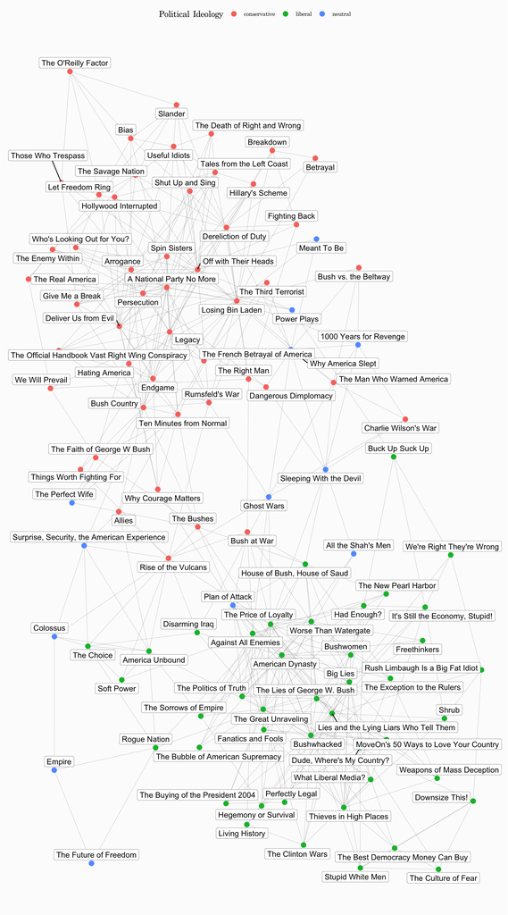

```r
ggraph(books_graph, layout="kk") +
  geom_edge_link(width=0.05) +
  geom_node_point(aes(col=political_ideology),size=3) +
  geom_node_label(aes(label=label), repel = T, label.size=0.1) +
  labs(col="Political Ideology")
```